# Chapter 8 Solutions Exercises

```r
pacman::p_load("tidyverse", "gapminder", "babynames", "sjPlot", "ggridges")
```

## 8.1 Chapter 1: Fundamentals

### 8.1.1 Exercise 1: Making your first Vector

Create a vector called `my_vector` with the values 1,2,3 and check is class.

```r
#create the vector
my_vector <- c(1,2,3)

#check the class
class(my_vector)
```

### 8.1.2 Exercise 2: Making your first matrix

Create a Matrix called `student`. This should contain information about the `name`, `age` and `major`. Make three vectors with three entries and bind them together to a the matrix `student`. Print the matrix. Choose the three names, age, and major by yourself:

```r
#Create the vectors
name <- c("James", "Elif", "Jonas")
age <- c("19", "17", "24")
major <- c("Political Science", "Data Science", "Physics")

#Create the matrix
student <- cbind(name, age, major)

#Or with the matrix command
student <- matrix(name, age, major)

#Print the matrix
print(student)
```

### 8.1.3 Exercise 3: `ifelse` function

Write an `ifelse` statement that checks if a given number is positive or negative. If the number is positive or 0, print “Number is positive”, otherwise print “Number is negative”. Feel free to decide if you want to use the `ifelse` function or the `ifelse` condition.

```r
#Assigning the number to the object "number"
number <- 0

#With ifelse() function
ifelse(number >= 0, "Number is positive", "Number is negative")

#With ifelse condition

if (number > 0) {
  print("Positive Number")
} else {
  print("Negative Number")
}
```

### 8.1.4 Exercise 4: `ifelse` ladders

Write an if-else ladder that categorizes a student’s grade based on their score. The grading criteria are as follows:

Score >= 90: “A” Score >= 80 and < 90: “B” Score >= 70 and < 80: “C” Score >= 60 and < 70: “D” Score < 60: “F”.

```r
#Defining the vector score
Score <- 90

#Defing ifelse ladder with ifelse() function
ifelse(Score >= 90, "A",
       ifelse(Score >= 80 & Score < 90, "B",
              ifelse(Score >= 70 & Score < 80, "C",
                     ifelse(Score >= 60 & Score < 70, "D",
                            ifelse(Score < 60, "F")))))

#Defining it with a ifelse condition
if (score >= 90) {
  print("A")
} else if (score >= 80 & score < 90) {
  print("B")
} else if (score >= 70 & score < 80) {
  print("C")
} else if (score >= 60 & score < 70) {
  print("D")
} else if (score < 60) {
  print("F")
}
```

## 8.2 Chapter 2: Data Manipulation

```r
pacman::p_load("tidyverse")
```

### 8.2.1 Exercise 1: Let’s wrangle kid

You are interested in discrimination and the perception of the judicial. More specifically, you want to know if people, who fell discriminated evaluate courts differently. Below you see a table with all variables you want to include in your analysis:

| **Variable** | **Description** | Scales |
| --- | --- | --- |
| **idnt** | Respondent’s identification number | unique number from 1-9000 |
| **year** | The year when the survey was conducted | only 2020 |
| **cntry** | Country | BE, BG, CH, CZ, EE, FI, FR,GB, GR, HR, HU, IE, IS, IT, LT,NL, NO, PT, SI, SK |
| **agea** | Age of the Respondent, calculated | Number of Age = 15-90 999 = Not available |
| **gndr** | Gender | 1 = Male; 2 = Female; 9 = No answer |
| **happy** | How happy are you | 0 (Extremly unhappy) - 10 (Extremly happy); 77 = Refusal; 88 = Don’t Know; 99 = No answer |
| **eisced** | Highest level of education, ES - ISCED | 0 = Not possible to harmonise into ES-ISCED; 1 (ES-ISCED I , less than lower secondary) - 7 (ES-ISCED V2, higher tertiary education, => MA level; 55 = Other; 77 = Refusal; 88 = Don’t know; 99 = No ans… |
| **netusoft** | Internet use, how often | 1 (Never) - 5 (Every day); 7 = Refusal; 8 = Don’t know; 9 = No answer |
| **trstprl** | Most people can be trusted or you can’t be too careful | 0 (You can’t be too careful) - 10 (Most people can be trusted); 77 = Refusal; 88 = Don’t Know; 99 = No answer |
| **lrscale** | Left-Right Placement | 0 (Left) - 10 (Right); 77 = Refusal; 88 = Don’t know; 99 = No answer |

1. Wrangle the data, and assign it to an object called **ess**.
2. Select the variables you need
3. Filter for Austria, Belgium, Denmark, Georgia, Iceland and the Russian Federation
4. Have a look at the codebook and code all irrelevant values as missing. If you have binary variables recode them from 1, 2 to 0 to 1
5. You want to build an extremism variable: You do so by subtracting 5 from the from the variable and squaring it afterwards. Call it extremism
6. Rename the variables to more intuitive names, don’t forget to name binary varaibles after the category which is on 1
7. drop all missing values
8. Check out your new dataset

```r
ess <- d1 %>%
  select(cntry, dscrgrp, cttresa, agea, gndr, eisced, lrscale) %>% #a
  filter(cntry %in% c("AT", "BE", "DK", "GE", "IS","RU")) %>% #b
  mutate(dscrgrp = case_when( #c
    dscrgrp == 1 ~ 0,
    dscrgrp == 2 ~ 1,
    dscrgrp %in% c(7, 8, 9) ~ NA_real_,
    TRUE ~ dscrgrp),
    cttresa = case_when(
    cttresa %in% c(77, 88, 99) ~ NA_real_,
    TRUE ~ cttresa),
    agea = case_when(
    agea == 999 ~ NA_real_,
    TRUE ~ agea),
    gndr = case_when(
      gndr == 1 ~ 0,
      gndr == 2 ~ 1,
      gndr == 9 ~ NA_real_
    ),
    eisced = case_when(
      eisced %in% c(55, 77, 88, 99) ~ NA_real_,
      TRUE ~ eisced),
    lrscale = case_when(
      lrscale %in% c(77, 88, 99) ~ NA_real_,
      TRUE ~ lrscale) #d, you could do this step also in a separate mutate function if you think that is more intuitive
  ) %>%
  mutate(extremism = (lrscale - 5)^2) %>%
  rename(discriminated = dscrgrp,
         court = cttresa,
         age = agea,
         female = gndr,
         education = eisced,
         lrscale = lrscale,
         extremism = extremism
         ) %>%
  drop_na()

#Checking the dataset
head(ess)
```

## 8.3 Chapter 3: Data Visualisation

In this exercise Section, we will work with the `babynames` and the `iris` package. This is a classic built-in package in R, which contains data from the Ronald Fisher’s 1936 Study “*The use of multiple measurements in taxonomic problems”.* It contains three plant species and four measured features for each species. Let us get an overview of the package:

```r
summary(iris)
```

```
##   Sepal.Length    Sepal.Width     Petal.Length
##  Min.   :4.300   Min.   :2.000   Min.   :1.000
##  1st Qu.:5.100   1st Qu.:2.800   1st Qu.:1.600
##  Median :5.800   Median :3.000   Median :4.350
##  Mean   :5.843   Mean   :3.057   Mean   :3.758
##  3rd Qu.:6.400   3rd Qu.:3.300   3rd Qu.:5.100
##  Max.   :7.900   Max.   :4.400   Max.   :6.900
##   Petal.Width          Species
##  Min.   :0.100   setosa    :50
##  1st Qu.:0.300   versicolor:50
##  Median :1.300   virginica :50
##  Mean   :1.199
##  3rd Qu.:1.800
##  Max.   :2.500
```

### 8.3.1 Exercise 1: Distributions

a. Plot a Chart, which shows the distribution of `Sepal.Length` over the `setosa` Species. Choose the type of distribution chart for yourself. **HINT:** Prepare the data first and then plot it.

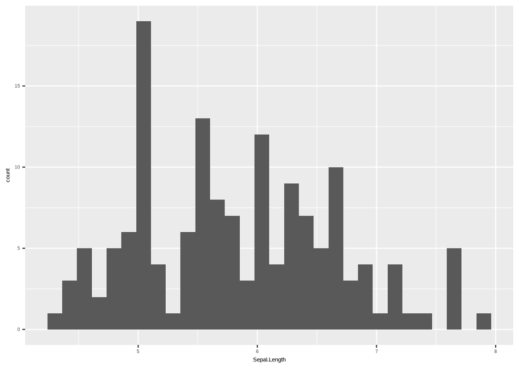

```r
#Filtering for setosa
d1 <- iris %>%
  filter(Species == "setosa")

#Histogram
ggplot(iris, aes(x = Sepal.Length)) +
  geom_histogram()
```

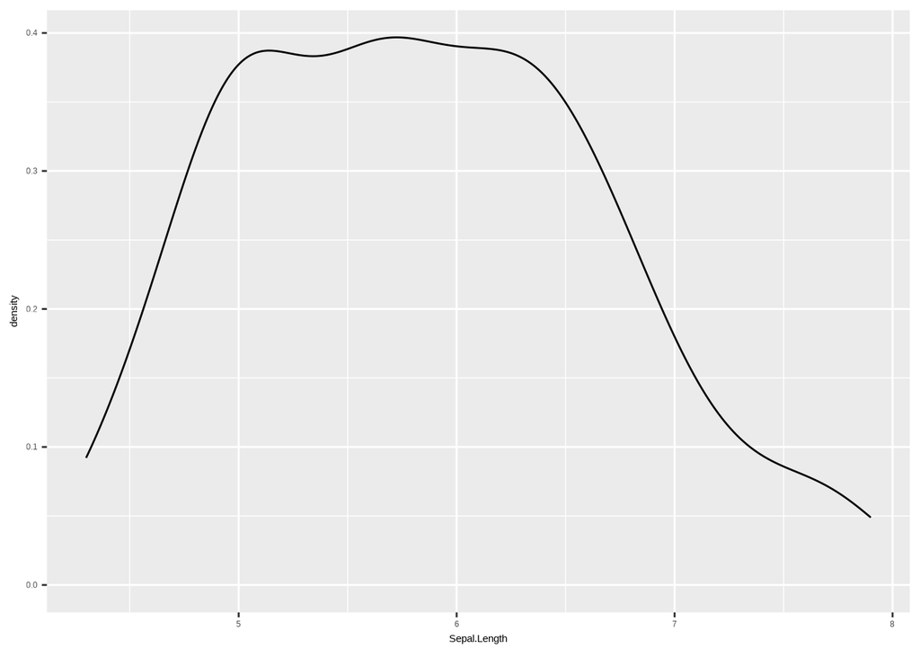

```r
#Density Plot
ggplot(iris, aes(x = Sepal.Length)) +
  geom_density()
```

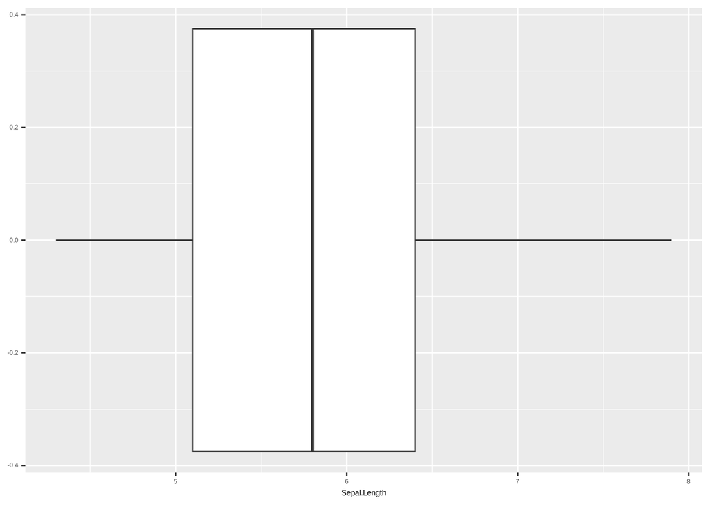

```r
#Boxplot
ggplot(iris, aes(x = Sepal.Length)) +
  geom_boxplot()
```

```r
# EDIT: You could also do everything in one step as shown below

#Histogram
#iris %>%
#filter(Species == "setosa") %>%
#ggplot(aes(x = Sepal.Length)) +
#geom_histogram()

#Density Plot
#iris %>%
#filter(Species == "setosa") %>%
#ggplot(aes(x = Sepal.Length)) +
#geom_density()

#Boxplot
#iris %>%
#filter(Species == "setosa") %>%
#ggplot(aes(x = Sepal.Length)) +
#geom_boxplot()
```

b. Now I want you to add the two other Species to the Plot. Make Sure, that every Species has a unique color.

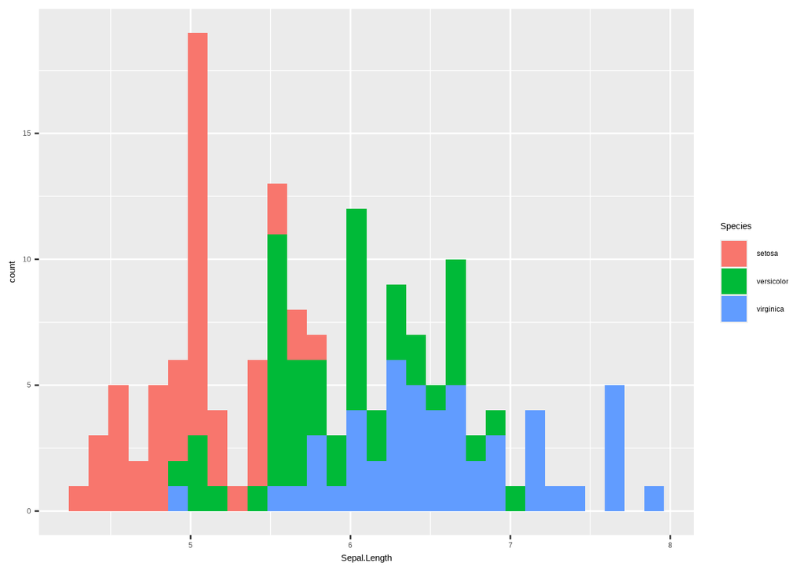

```r
#Histogram
ggplot(iris, aes(x = Sepal.Length, fill = Species)) +
  geom_histogram()
```

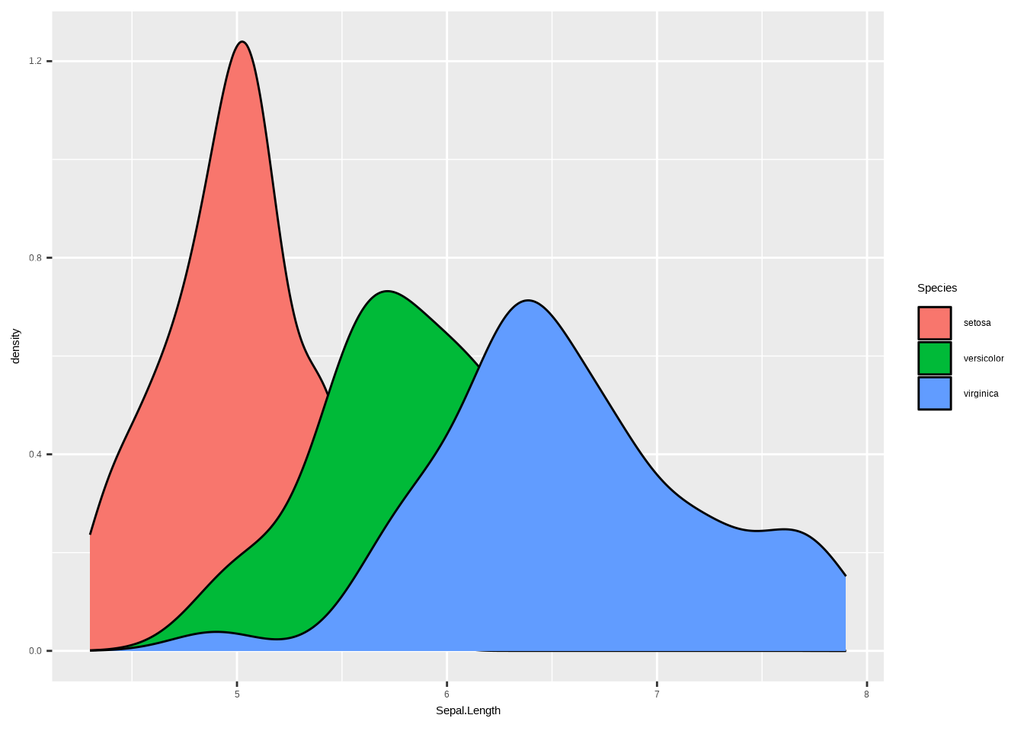

```r
#Density Plot
ggplot(iris, aes(x = Sepal.Length, fill = Species)) +
  geom_density()
```

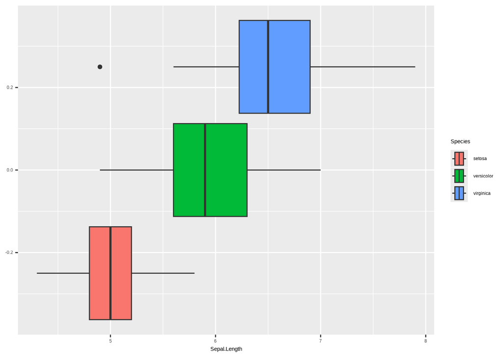

```r
#Boxplot
ggplot(iris, aes(x = Sepal.Length, fill = Species)) +
  geom_boxplot()
```

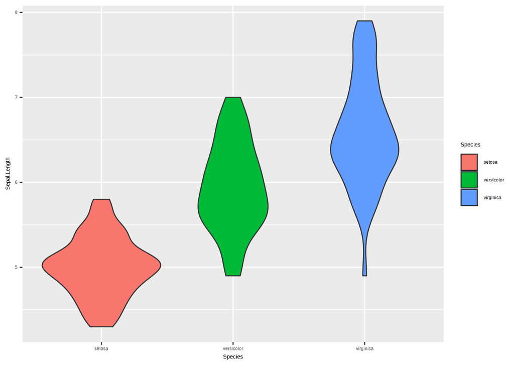

```r
#Violin Plot
ggplot(iris, aes(x = Species, y = Sepal.Length, fill = Species)) +
  geom_violin()
```

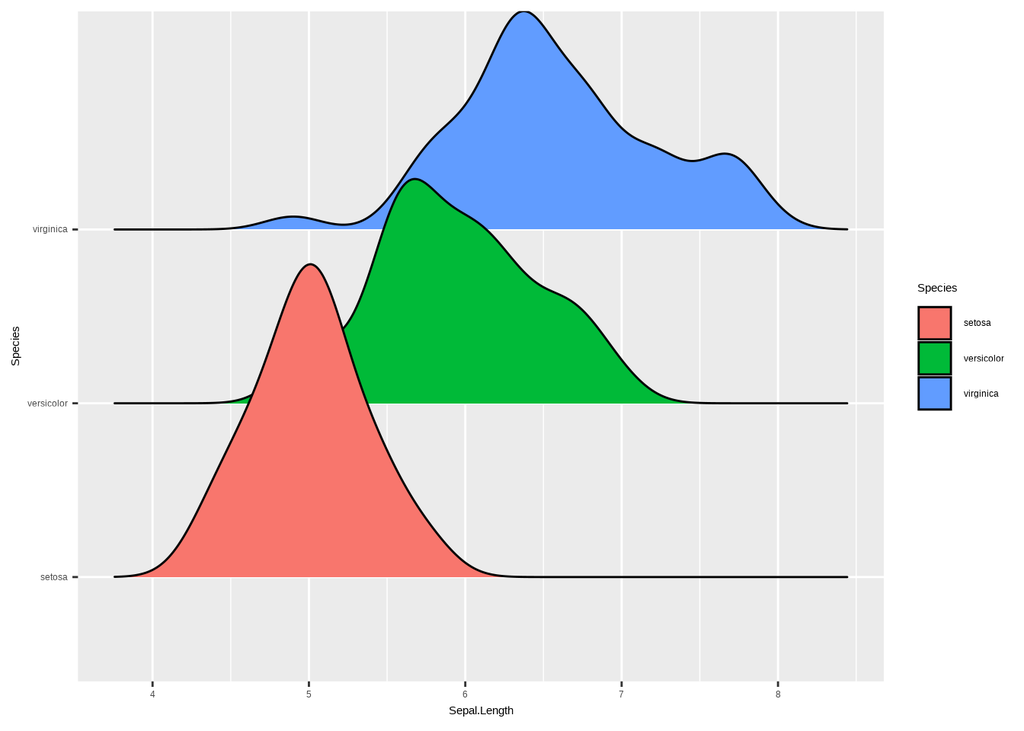

```r
#Ridgeline Plot
ggplot(iris, aes(x = Sepal.Length, y = Species, fill = Species)) +
  geom_density_ridges()
```

c. Make a nice Plot! Give the Plot a meaningful title, meaningful labels for the x-axis and the y-axis and play around with the colors.

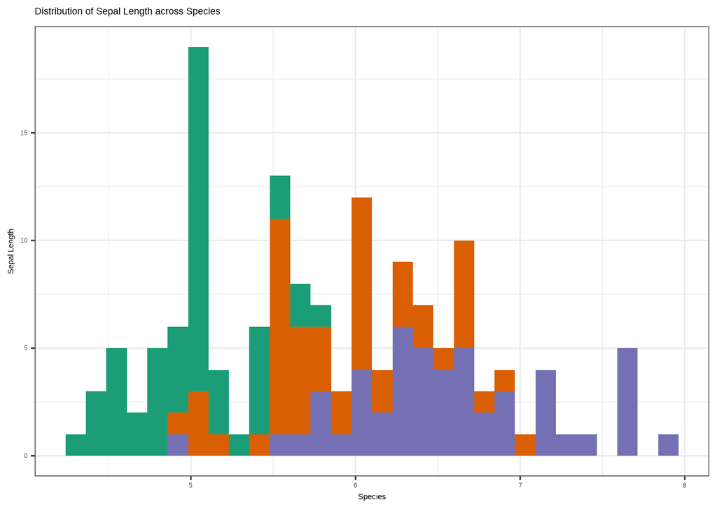

```r
#Histogram
ggplot(iris, aes(x = Sepal.Length, fill = Species)) +
  geom_histogram() +
  labs(
    x = "Species",
    y = "Sepal Length",
    title = "Distribution of Sepal Length across Species"
  ) +
  theme_bw() +
  theme(
    legend.position = "none"
  ) +
  scale_fill_brewer(palette = "Dark2")
```

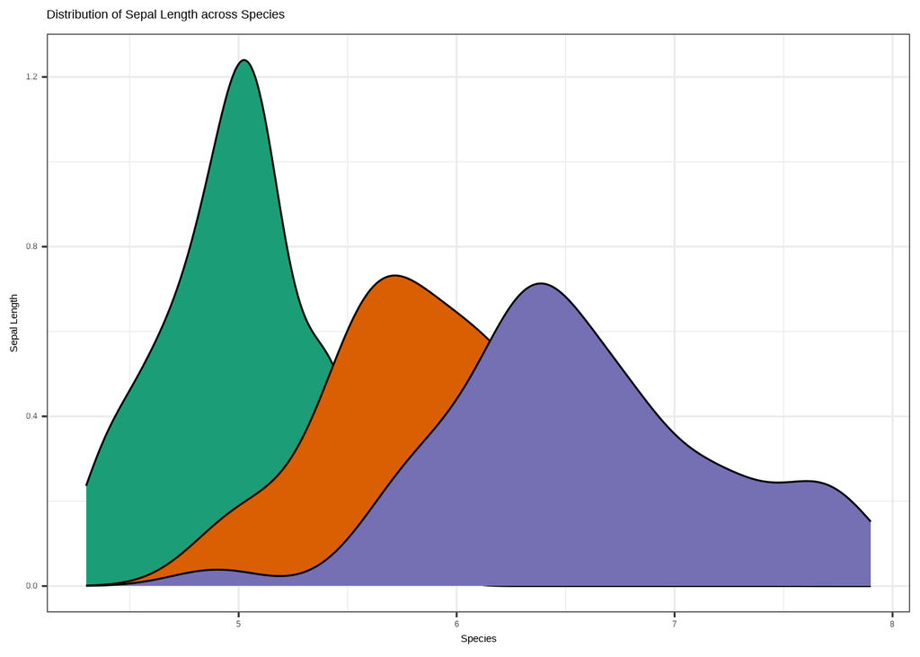

```r
#Density Plot
ggplot(iris, aes(x = Sepal.Length, fill = Species)) +
  geom_density() +
  labs(
    x = "Species",
    y = "Sepal Length",
    title = "Distribution of Sepal Length across Species"
  ) +
  theme_bw() +
  theme(
    legend.position = "none"
  ) +
  scale_fill_brewer(palette = "Dark2")
```